# Data Science Capstone Data Analysis

Kyla Mazzotta

2025-12-12

# Data

- A dataset containing web scraped race results from the UTMB website
- Originally a json object, was then loaded before preprocessing

```r
utmb_data <- fromJSON("utmb-race-data-raw.json", flatten=TRUE)
```

## Data Preprocessing

- Prior research shows that ultra marathons tend to be dominated by American and European athletes as there is little to no monetary incentive to perform well, a key factor differentiating marathon participants from ultra marathon participants.
- The main focus for this statistical analysis was therefore to isolate races that occurred in the United States to reduce potential variability in results across finish times with differen participant demographics country-wise.
- The UTMB race results were then filtered to only contain data on races located in the US

```r
us_races <- utmb_data[
  sapply(utmb_data, function(x) {
    grepl("United States|USA|US$", x$`City / Country`, ignore.case = TRUE)
  })
]
```

- The dataset of US races was then converted into a data frame to prepare for exploratory data analysis (EDA)
- The original dataset contained information on the number of participants in. each age 4-year age group. Since the there is little variation in finish times with such small age groups, they were consolidated into three bins:
  - Under 35
  - 35 - 59
  - 60 and older
- Each age group bin was also adjusted to reoprt the percentage of athletes in each age group as opposed to number as the races vary in size and participant breakdowns.

```r
us_df <- imap_dfr(us_races, ~{
  results <- .x$Results
  total_age <- sum(unlist(.x$Age))
  tibble(
    race_id        = .y,
    city_country   = .x$`City / Country`,
    date           = .x$Date,
    distance       = .x$Distance,
    elevation_gain = .x$`Elevation Gain`,
    n_participants = length(results),
    mean_time_hrs      = mean(results, na.rm = TRUE),
    median_time_hrs    = median(results, na.rm = TRUE),
    sd_time            = sd(results, na.rm = TRUE),
    min_time_hrs       = min(results, na.rm = TRUE),
    max_time_hrs       = max(results, na.rm = TRUE),
    pct_women      = .x$Sex$Women / sum(unlist(.x$Sex)),
    pct_age_u35     = sum(unlist(.x$Age[c("U18", "U20", "20-34")]), na.rm = TRUE) / total_age,
    pct_age_35_59     = sum(unlist(.x$Age[c("35-39", "40-44", "45-49", "50-54", "55-59")]), na.rm = TRUE) / total_age,
    pct_age_60_plus = sum(unlist(.x$Age[c("60-64", "65-69", "70-74", "75-79", "80+")]), na.rm = TRUE) / total_age
  )
})
```

- Distance and elevation variables were also converted from character strings to variables for analysis.

```r
colnames(us_df)[4] <- "distance_km"
colnames(us_df)[5] <- "elevation_gain_m"

us_df <- us_df %>%
  mutate(
    distance_km = parse_number(distance_km),
    elevation_gain_m = parse_number(elevation_gain_m)
  )
```

- UTMB races are not implicitly ultra marathons, therefore race distances vary anywhere from 4.7 to 336.5 kilometers long.
- To ensure that only ultra marathons were being considered, only races with distances greater than or equal to 50 km.

```r
us_df <- us_df %>% filter(distance_km >= 50)
```

```r
# min number of participants
min(us_df$n_participants, na.rm = TRUE)
# 1

# max number of participants
max(us_df$n_participants, na.rm = TRUE)
# 1000

# distribution
summary(us_df$n_participants)
```

- The 50th percentile was calculated to be races with 84 participants.
- It was therefore determined that races with 85 or more participants would be analyzed as these races were sufficiently large enough while not eliminating too many data points.

```r
us_df <- us_df %>% filter(n_participants >= 85)
```

- The most common ultra marathon races are typically 50 km, 50 mi, 100 km, and 100 mi. Since these distances are never exact, distance (along with elevation gain) were treated as continuous variables, therefore they were centered to measure deviations from the mean to help with:
  - model stability
  - make interpretations of regression coefficients meaningful
  - reducing multicollinearity

```r
mean_distance_km <- mean(us_df$distance_km)
mean_elevation_m <- mean(us_df$elevation_gain_m)

us_df$distance_km <- us_df$distance_km - mean_distance_km
us_df$elevation_gain_m <- us_df$elevation_gain_m - mean_elevation_m
```

- After centering, distance and elevation baselines became:
  - 85.0581 kilometers
  - 2564.2234 meters

```r
# table to show the first 5 rows
table_df <- us_df |>
  dplyr::select(
    race_id,
    mean_time_hrs,
    distance_km,
    elevation_gain_m,
    pct_women,
    pct_age_u35,
    pct_age_35_59,
    pct_age_60_plus
  ) |>
  slice_head(n = 5)

# create pretty table
gt_table <- gt(table_df) |>
  tab_header(
    title = "Sample of UTMB Race-Level Data",
    subtitle = "First 5 Rows — Centered Predictors Included"
  ) |>
  tab_spanner(
    label = "Centered Predictors",
    columns = c(distance_km, elevation_gain_m)
  ) |>
  tab_spanner(
    label = "Participant Demographics (%)",
    columns = c(pct_women, pct_age_u35, pct_age_35_59, pct_age_60_plus)
  ) |>
  cols_label(
    race_id = "Race ID",
    mean_time_hrs = "Mean Finish Time (hrs)",
    distance_km = "Distance (km, centered)",
    elevation_gain_m = "Elevation Gain (m, centered)",
    pct_women = "% Women",
    pct_age_u35 = "Under 35",
    pct_age_35_59 = "35–59",
    pct_age_60_plus = "60+"
  ) |>
  fmt_number(
    columns = c(distance_km, elevation_gain_m, pct_women, pct_age_u35, pct_age_35_59, pct_age_60_plus),
    decimals = 4
  ) |>
  opt_stylize(style = 6, color = "blue") |>
  tab_options(
    heading.align = "center",
    heading.background.color = "grey",
    heading.title.font.size = px(20)
  )

gt_table
```

Sample of UTMB Race-Level Data

First 5 Rows — Centered Predictors Included

| Race ID | Mean Finish Time (hrs) | Centered Predictors Distance (km, centered) | Centered Predictors Elevation Gain (m, centered) | Participant Demographics (%) % Women | Participant Demographics (%) Under 35 | Participant Demographics (%) 35–59 | Participant Demographics (%) 60+ |
| --- | --- | --- | --- | --- | --- | --- | --- |
| 10129.2018 | 8.258698 | −35.0581 | 185.7766 | 0.3333 | 0.3750 | 0.6250 | 0.0000 |
| 10129.2019 | 8.553171 | −35.0581 | 185.7766 | 0.4161 | 0.3758 | 0.5839 | 0.0403 |
| 10129.2020 | 7.849280 | −35.0581 | 185.7766 | 0.2845 | 0.4310 | 0.5431 | 0.0259 |
| 1014.2014 | 10.187414 | −4.0581 | −964.2234 | 0.2664 | 0.2587 | 0.5792 | 0.1622 |
| 1014.2015 | 10.186978 | −4.0581 | −964.2234 | 0.2316 | 0.2316 | 0.7158 | 0.0526 |

# Exploratory Data Analysis

## Correlation Matrix

- A correlation matrix was made to determine which factors should be considered for inclusion in regression
- Note that the Under 35 age group is excluded to prevent perfect multicillinearity.

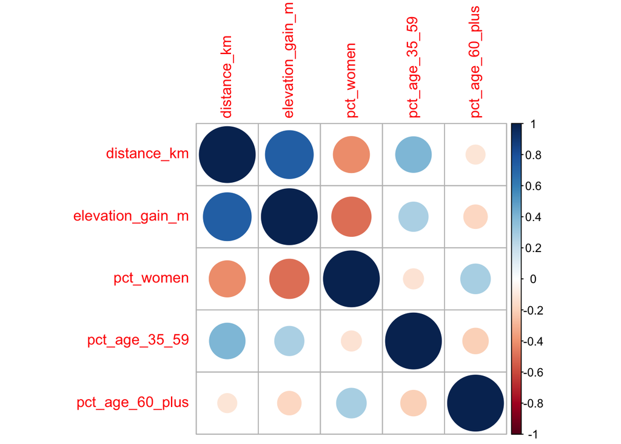

```r
correlation_matrix <- us_df %>% dplyr::select(distance_km, elevation_gain_m, pct_women, pct_age_35_59, pct_age_60_plus)

corrplot(cor(correlation_matrix))
```

## Preliminary Scatterplots

- Scatterplots of race distance and elevation against mean finish time were constructed to produce a baseline idea of variable relationships

### Distance vs Mean Finish Time

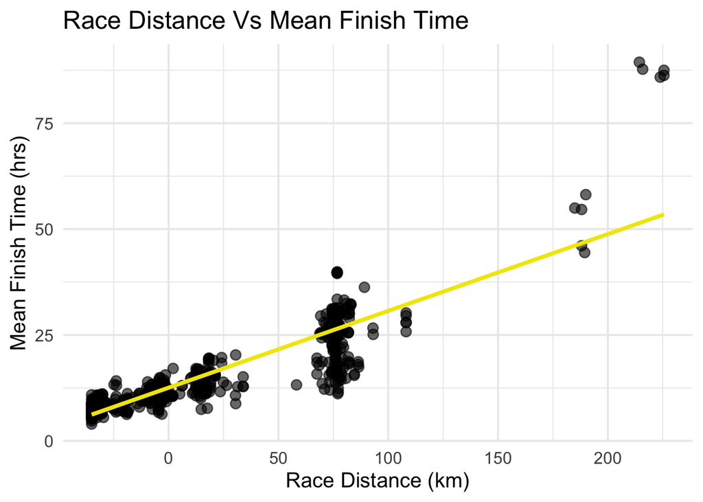

```r
ggplot(us_df, aes(x = distance_km, y = mean_time_hrs)) +
  geom_point(alpha = 0.6, size = 3) +
  geom_smooth(method = "lm", se = FALSE, col = "#f1e60e") +
  labs(
    x = "Race Distance (km)",
    y = "Mean Finish Time (hrs)",
    title = "Race Distance Vs Mean Finish Time"
  ) +
  theme_minimal(base_size = 15)
```

- The scatterplot indicates potential nonlinear relationship between distance and mean finish time.

### Elevation Gain vs Mean Finish Time

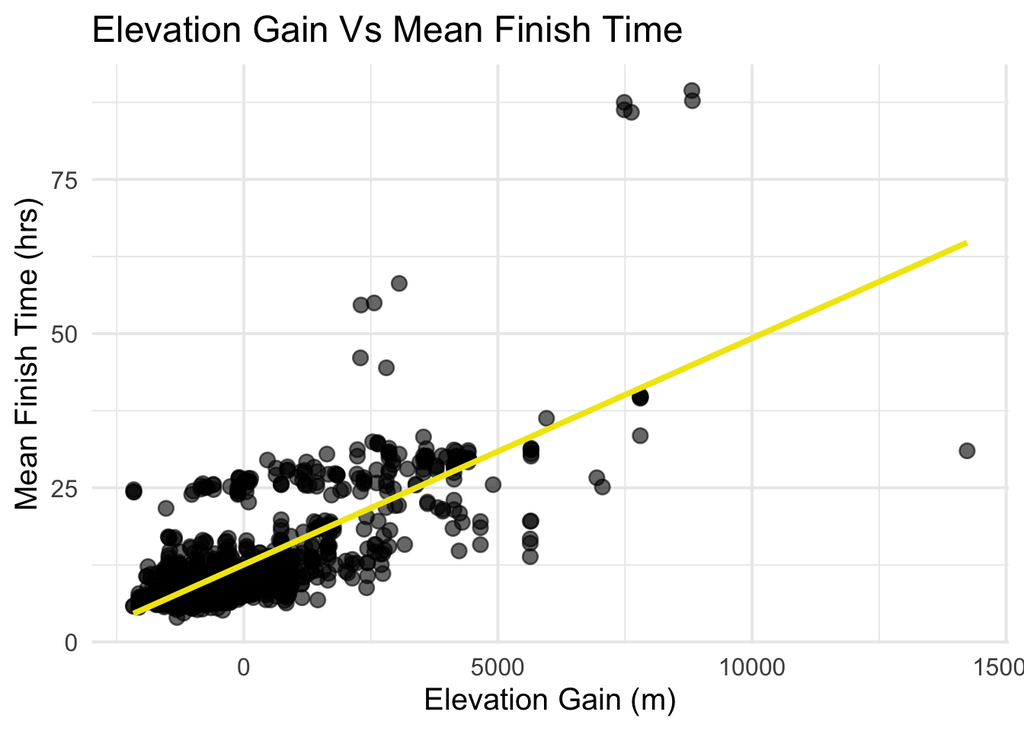

```r
ggplot(us_df, aes(x = elevation_gain_m, y = mean_time_hrs)) +
  geom_point(alpha = 0.6, size = 3) +
  geom_smooth(method = "lm", se = FALSE, col = "#f1e60e") +
  labs(
    x = "Elevation Gain (m)",
    y = "Mean Finish Time (hrs)",
    title = "Elevation Gain Vs Mean Finish Time"
  ) +
  theme_minimal(base_size = 15)
```

- The scatter plot displays a moderately positive linear relationship between elevation gain and mean with time with a couple potential outliers

# Regression

## Preliminary Regression - Parsimonious Model

remember that we are using pct_u35 as the base so it is not included in models (to avoid perfect multicollinearity)

```r
prelim_regression <- lm(mean_time_hrs ~ distance_km + I(distance_km^2) + elevation_gain_m +
                          pct_women + pct_age_35_59 + pct_age_60_plus, data = us_df)
summary(prelim_regression)
```

```
##
## Call:
## lm(formula = mean_time_hrs ~ distance_km + I(distance_km^2) +
##     elevation_gain_m + pct_women + pct_age_35_59 + pct_age_60_plus,
##     data = us_df)
##
## Residuals:
##      Min       1Q   Median       3Q      Max
## -15.2897  -0.9539   0.0285   1.3338  14.8097
##
## Coefficients:
##                    Estimate Std. Error t value Pr(>|t|)
## (Intercept)       1.057e+01  7.952e-01  13.291   <2e-16 ***
## distance_km       1.054e-01  3.585e-03  29.394   <2e-16 ***
## I(distance_km^2)  7.398e-04  2.845e-05  26.001   <2e-16 ***
## elevation_gain_m  7.546e-04  7.126e-05  10.590   <2e-16 ***
## pct_women        -2.082e-01  1.038e+00  -0.201    0.841
## pct_age_35_59     1.079e+00  1.075e+00   1.004    0.316
## pct_age_60_plus  -2.523e+00  1.752e+00  -1.440    0.150
## ---
## Signif. codes:  0 '***' 0.001 '**' 0.01 '*' 0.05 '.' 0.1 ' ' 1
##
## Residual standard error: 2.815 on 1188 degrees of freedom
## Multiple R-squared:  0.8983, Adjusted R-squared:  0.8978
## F-statistic:  1748 on 6 and 1188 DF,  p-value: < 2.2e-16
```

### Residuals Plots Indicating Non-normality

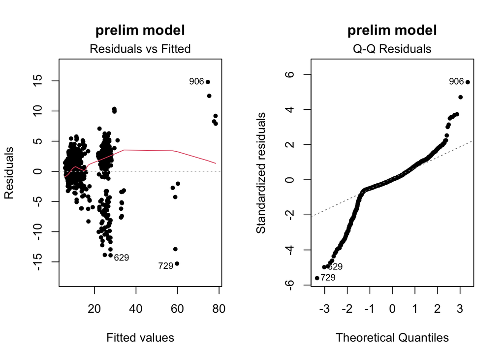

```r
par(mfrow = c(1,2))
plot(prelim_regression, which=1, main="prelim model", pch=20)
plot(prelim_regression, which=2, main="prelim model", pch=20)
```

## Log Model Moving Forward

- Due to the data not appearing to be normally distributed, a log model will be run moving forward.

```r
us_df <- us_df %>%
  mutate(log_mean_time = log(mean_time_hrs))
```

### Parsimonious Model

```r
log_regression <- lm(log_mean_time ~ distance_km + I(distance_km^2) + elevation_gain_m +
                          pct_women + pct_age_35_59 + pct_age_60_plus, data = us_df)

summary(log_regression)
```

```
##
## Call:
## lm(formula = log_mean_time ~ distance_km + I(distance_km^2) +
##     elevation_gain_m + pct_women + pct_age_35_59 + pct_age_60_plus,
##     data = us_df)
##
## Residuals:
##      Min       1Q   Median       3Q      Max
## -0.79419 -0.09046  0.01595  0.11109  0.50661
##
## Coefficients:
##                    Estimate Std. Error t value Pr(>|t|)
## (Intercept)       2.402e+00  4.744e-02  50.645   <2e-16 ***
## distance_km       1.101e-02  2.138e-04  51.466   <2e-16 ***
## I(distance_km^2) -1.932e-05  1.697e-06 -11.383   <2e-16 ***
## elevation_gain_m  3.543e-05  4.251e-06   8.335   <2e-16 ***
## pct_women         7.844e-02  6.192e-02   1.267    0.205
## pct_age_35_59    -1.224e-03  6.414e-02  -0.019    0.985
## pct_age_60_plus  -1.444e-01  1.045e-01  -1.382    0.167
## ---
## Signif. codes:  0 '***' 0.001 '**' 0.01 '*' 0.05 '.' 0.1 ' ' 1
##
## Residual standard error: 0.1679 on 1188 degrees of freedom
## Multiple R-squared:  0.889,  Adjusted R-squared:  0.8884
## F-statistic:  1585 on 6 and 1188 DF,  p-value: < 2.2e-16
```

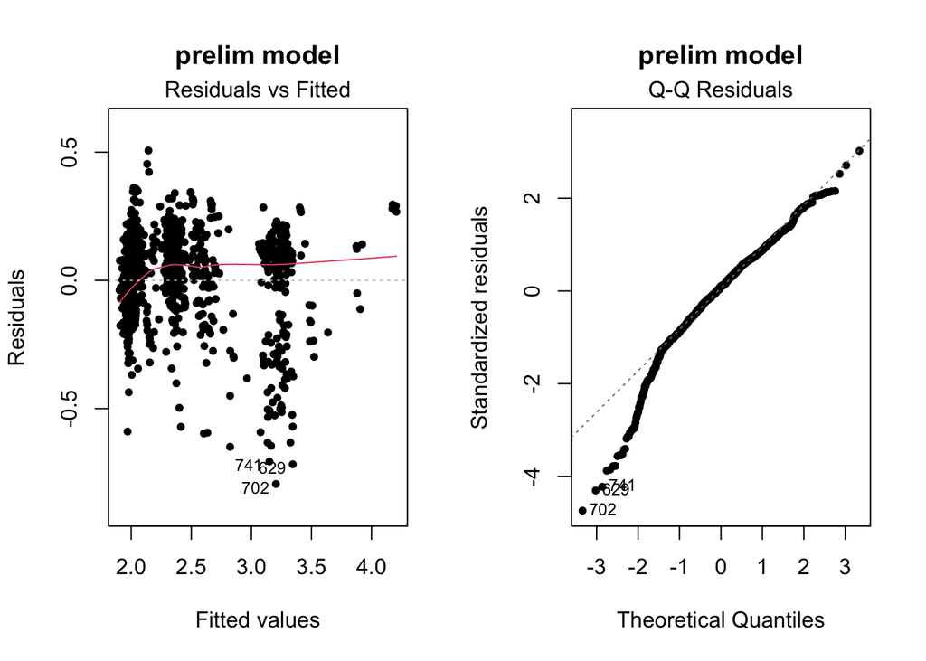

```r
par(mfrow = c(1,2))
plot(log_regression, which=1, main="prelim model", pch=20)
plot(log_regression, which=2, main="prelim model", pch=20)
```

### Full Model

- Regressions with full model (interaction and higher order terms), adding only terms that are hypothesized to be significant and relevant.

```r
full_log_regression <- lm(log_mean_time ~ distance_km + I(distance_km^2) + elevation_gain_m +
                          pct_women + pct_age_35_59 + pct_age_60_plus +
                          distance_km*elevation_gain_m + distance_km*pct_women +
                          elevation_gain_m*pct_women, data = us_df)
summary(full_log_regression)
```

```
##
## Call:
## lm(formula = log_mean_time ~ distance_km + I(distance_km^2) +
##     elevation_gain_m + pct_women + pct_age_35_59 + pct_age_60_plus +
##     distance_km * elevation_gain_m + distance_km * pct_women +
##     elevation_gain_m * pct_women, data = us_df)
##
## Residuals:
##      Min       1Q   Median       3Q      Max
## -0.78075 -0.08917  0.01458  0.11163  0.51964
##
## Coefficients:
##                                Estimate Std. Error t value Pr(>|t|)
## (Intercept)                   2.423e+00  4.805e-02  50.416  < 2e-16 ***
## distance_km                   9.389e-03  6.351e-04  14.785  < 2e-16 ***
## I(distance_km^2)             -1.490e-05  2.924e-06  -5.096 4.04e-07 ***
## elevation_gain_m              9.313e-05  1.518e-05   6.134 1.17e-09 ***
## pct_women                     4.085e-02  6.409e-02   0.637   0.5240
## pct_age_35_59                -2.428e-02  6.440e-02  -0.377   0.7062
## pct_age_60_plus              -1.748e-01  1.048e-01  -1.667   0.0957 .
## distance_km:elevation_gain_m -1.365e-07  8.572e-08  -1.592   0.1117
## distance_km:pct_women         5.189e-03  2.046e-03   2.537   0.0113 *
## elevation_gain_m:pct_women   -2.043e-04  5.119e-05  -3.992 6.97e-05 ***
## ---
## Signif. codes:  0 '***' 0.001 '**' 0.01 '*' 0.05 '.' 0.1 ' ' 1
##
## Residual standard error: 0.167 on 1185 degrees of freedom
## Multiple R-squared:  0.8905, Adjusted R-squared:  0.8896
## F-statistic:  1070 on 9 and 1185 DF,  p-value: < 2.2e-16
```

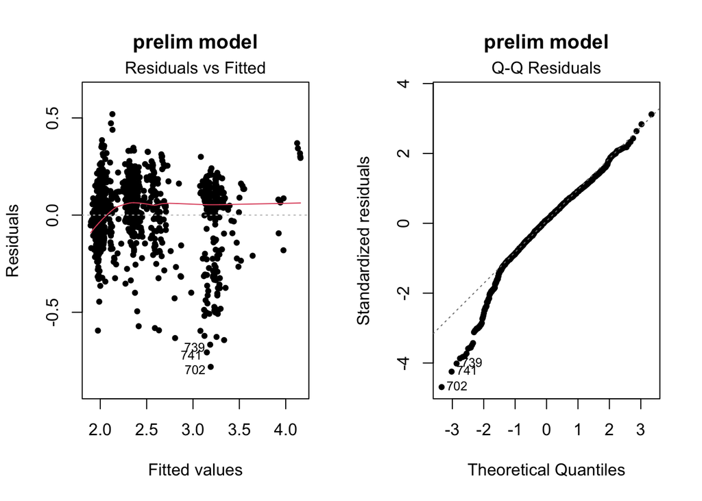

```r
par(mfrow = c(1,2))
plot(full_log_regression, which=1, main="prelim model", pch=20)
plot(full_log_regression, which=2, main="prelim model", pch=20)
```

### Stepwise Regression (from both directions)

```r
log_both_step_model <- stepAIC(full_log_regression, direction = "both")
```

```
## Start:  AIC=-4267.96
## log_mean_time ~ distance_km + I(distance_km^2) + elevation_gain_m +
##     pct_women + pct_age_35_59 + pct_age_60_plus + distance_km *
##     elevation_gain_m + distance_km * pct_women + elevation_gain_m *
##     pct_women
##
##                                Df Sum of Sq    RSS     AIC
## - pct_age_35_59                 1   0.00396 33.042 -4269.8
## <none>                                      33.038 -4268.0
## - distance_km:elevation_gain_m  1   0.07065 33.108 -4267.4
## - pct_age_60_plus               1   0.07750 33.115 -4267.2
## - distance_km:pct_women         1   0.17939 33.217 -4263.5
## - elevation_gain_m:pct_women    1   0.44421 33.482 -4254.0
## - I(distance_km^2)              1   0.72389 33.762 -4244.1
##
## Step:  AIC=-4269.82
## log_mean_time ~ distance_km + I(distance_km^2) + elevation_gain_m +
##     pct_women + pct_age_60_plus + distance_km:elevation_gain_m +
##     distance_km:pct_women + elevation_gain_m:pct_women
##
##                                Df Sum of Sq    RSS     AIC
## <none>                                      33.042 -4269.8
## - distance_km:elevation_gain_m  1   0.07254 33.114 -4269.2
## - pct_age_60_plus               1   0.07357 33.115 -4269.2
## + pct_age_35_59                 1   0.00396 33.038 -4268.0
## - distance_km:pct_women         1   0.17742 33.219 -4265.4
## - elevation_gain_m:pct_women    1   0.44025 33.482 -4256.0
## - I(distance_km^2)              1   0.71999 33.762 -4246.1
```

```r
summary(log_both_step_model)
```

```
##
## Call:
## lm(formula = log_mean_time ~ distance_km + I(distance_km^2) +
##     elevation_gain_m + pct_women + pct_age_60_plus + distance_km:elevation_gain_m +
##     distance_km:pct_women + elevation_gain_m:pct_women, data = us_df)
##
## Residuals:
##      Min       1Q   Median       3Q      Max
## -0.78083 -0.09029  0.01419  0.11212  0.52128
##
## Coefficients:
##                                Estimate Std. Error t value Pr(>|t|)
## (Intercept)                   2.406e+00  1.873e-02 128.432  < 2e-16 ***
## distance_km                   9.372e-03  6.331e-04  14.804  < 2e-16 ***
## I(distance_km^2)             -1.481e-05  2.913e-06  -5.084 4.30e-07 ***
## elevation_gain_m              9.281e-05  1.515e-05   6.124 1.24e-09 ***
## pct_women                     3.932e-02  6.394e-02   0.615   0.5387
## pct_age_60_plus              -1.667e-01  1.026e-01  -1.625   0.1044
## distance_km:elevation_gain_m -1.381e-07  8.558e-08  -1.614   0.1069
## distance_km:pct_women         5.156e-03  2.043e-03   2.524   0.0117 *
## elevation_gain_m:pct_women   -2.025e-04  5.094e-05  -3.975 7.46e-05 ***
## ---
## Signif. codes:  0 '***' 0.001 '**' 0.01 '*' 0.05 '.' 0.1 ' ' 1
##
## Residual standard error: 0.1669 on 1186 degrees of freedom
## Multiple R-squared:  0.8905, Adjusted R-squared:  0.8897
## F-statistic:  1205 on 8 and 1186 DF,  p-value: < 2.2e-16
```

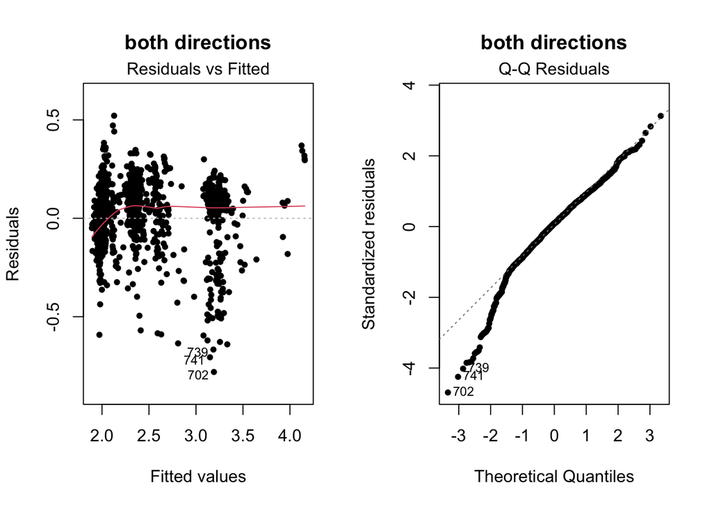

```r
par(mfrow = c(1,2))
plot(log_both_step_model, which=1, main="both directions", pch=20)
plot(log_both_step_model, which=2, main="both directions", pch=20)
```

#### Checking VIF of Stepwise Regression Model

```r
vif(log_backward_step_model, type = "predictor")
```

```
## GVIFs computed for predictors
```

```
##                      GVIF Df GVIF^(1/(2*Df))
## distance_km      1.110801  7        1.007534
## elevation_gain_m 1.110801  7        1.007534
## pct_women        1.110801  7        1.007534
## pct_age_60_plus  1.110801  1        1.053946
##                                                 Interacts With
## distance_km      I(distance_km^2), elevation_gain_m, pct_women
## elevation_gain_m                        distance_km, pct_women
## pct_women                        distance_km, elevation_gain_m
## pct_age_60_plus                                           --
##                                          Other Predictors
## distance_km                               pct_age_60_plus
## elevation_gain_m                          pct_age_60_plus
## pct_women                                 pct_age_60_plus
## pct_age_60_plus  distance_km, elevation_gain_m, pct_women
```

#### Checking for Outliers

```r
cooks_distance <- cooks.distance(log_both_step_model)
threshold <- 4 / nrow(us_df)
influential_observations <- which(cooks_distance > threshold)
```

- Outliers were checked for using Cook’s Distance with a threshold criteria of 0.0033

### Stepwise Regression with Outliers Removed

- Outliers were then removed and stepwise regression from both directions was then run to check model improvement.

```r
keep_rows <- which(cooks_distance <= threshold)
us_df_no_outliers <- us_df[keep_rows, ]
```

```r
no_outlier_log_regression <- lm(log_mean_time ~ distance_km + I(distance_km^2) + elevation_gain_m +
                          pct_women + pct_age_35_59 + pct_age_60_plus +
                          distance_km*elevation_gain_m + distance_km*pct_women +
                          elevation_gain_m*pct_women, data = us_df_no_outliers)

outlierless_log_both_step_model <- stepAIC(no_outlier_log_regression, direction = "both")
```

```
## Start:  AIC=-4535.9
## log_mean_time ~ distance_km + I(distance_km^2) + elevation_gain_m +
##     pct_women + pct_age_35_59 + pct_age_60_plus + distance_km *
##     elevation_gain_m + distance_km * pct_women + elevation_gain_m *
##     pct_women
##
##                                Df Sum of Sq    RSS     AIC
## - pct_age_60_plus               1   0.00024 19.344 -4537.9
## - pct_age_35_59                 1   0.00255 19.346 -4537.7
## - distance_km:pct_women         1   0.00850 19.352 -4537.4
## <none>                                      19.343 -4535.9
## - elevation_gain_m:pct_women    1   0.13276 19.476 -4530.2
## - distance_km:elevation_gain_m  1   0.51286 19.856 -4508.5
## - I(distance_km^2)              1   0.92339 20.267 -4485.6
##
## Step:  AIC=-4537.88
## log_mean_time ~ distance_km + I(distance_km^2) + elevation_gain_m +
##     pct_women + pct_age_35_59 + distance_km:elevation_gain_m +
##     distance_km:pct_women + elevation_gain_m:pct_women
##
##                                Df Sum of Sq    RSS     AIC
## - pct_age_35_59                 1   0.00293 19.347 -4539.7
## - distance_km:pct_women         1   0.00830 19.352 -4539.4
## <none>                                      19.344 -4537.9
## + pct_age_60_plus               1   0.00024 19.343 -4535.9
## - elevation_gain_m:pct_women    1   0.13253 19.476 -4532.2
## - distance_km:elevation_gain_m  1   0.52069 19.864 -4510.1
## - I(distance_km^2)              1   0.92786 20.272 -4487.3
##
## Step:  AIC=-4539.71
## log_mean_time ~ distance_km + I(distance_km^2) + elevation_gain_m +
##     pct_women + distance_km:elevation_gain_m + distance_km:pct_women +
##     elevation_gain_m:pct_women
##
##                                Df Sum of Sq    RSS     AIC
## - distance_km:pct_women         1   0.00858 19.355 -4541.2
## <none>                                      19.347 -4539.7
## + pct_age_35_59                 1   0.00293 19.344 -4537.9
## + pct_age_60_plus               1   0.00062 19.346 -4537.7
## - elevation_gain_m:pct_women    1   0.13564 19.482 -4533.9
## - distance_km:elevation_gain_m  1   0.51896 19.866 -4512.0
## - I(distance_km^2)              1   0.93827 20.285 -4488.6
##
## Step:  AIC=-4541.21
## log_mean_time ~ distance_km + I(distance_km^2) + elevation_gain_m +
##     pct_women + distance_km:elevation_gain_m + elevation_gain_m:pct_women
##
##                                Df Sum of Sq    RSS     AIC
## <none>                                      19.355 -4541.2
## + distance_km:pct_women         1   0.00858 19.347 -4539.7
## + pct_age_35_59                 1   0.00321 19.352 -4539.4
## + pct_age_60_plus               1   0.00026 19.355 -4539.2
## - elevation_gain_m:pct_women    1   0.16544 19.521 -4533.7
## - distance_km:elevation_gain_m  1   0.53072 19.886 -4512.9
## - I(distance_km^2)              1   0.95482 20.310 -4489.2
```

```r
summary(outlierless_log_both_step_model)
```

```
##
## Call:
## lm(formula = log_mean_time ~ distance_km + I(distance_km^2) +
##     elevation_gain_m + pct_women + distance_km:elevation_gain_m +
##     elevation_gain_m:pct_women, data = us_df_no_outliers)
##
## Residuals:
##      Min       1Q   Median       3Q      Max
## -0.65988 -0.07322  0.00263  0.08543  0.37731
##
## Coefficients:
##                                Estimate Std. Error t value Pr(>|t|)
## (Intercept)                   2.445e+00  1.634e-02 149.564  < 2e-16 ***
## distance_km                   1.210e-02  2.015e-04  60.056  < 2e-16 ***
## I(distance_km^2)             -2.503e-05  3.375e-06  -7.417 2.38e-13 ***
## elevation_gain_m              8.128e-05  1.181e-05   6.882 9.80e-12 ***
## pct_women                     4.296e-02  5.676e-02   0.757  0.44929
## distance_km:elevation_gain_m -5.275e-07  9.540e-08  -5.529 4.00e-08 ***
## elevation_gain_m:pct_women   -1.187e-04  3.846e-05  -3.087  0.00207 **
## ---
## Signif. codes:  0 '***' 0.001 '**' 0.01 '*' 0.05 '.' 0.1 ' ' 1
##
## Residual standard error: 0.1318 on 1115 degrees of freedom
## Multiple R-squared:  0.9225, Adjusted R-squared:  0.9221
## F-statistic:  2211 on 6 and 1115 DF,  p-value: < 2.2e-16
```

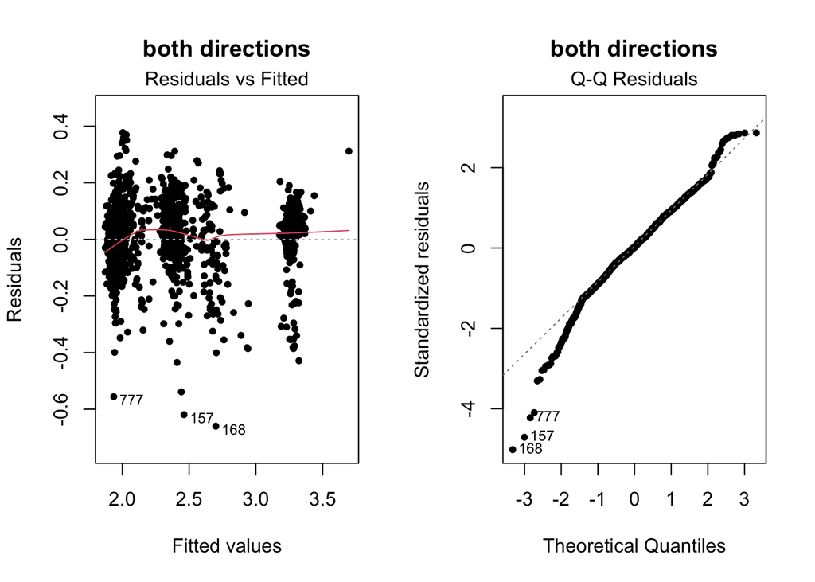

```r
par(mfrow = c(1,2))
plot(outlierless_log_both_step_model, which=1, main="both directions", pch=20)
plot(outlierless_log_both_step_model, which=2, main="both directions", pch=20)
```

#### VIF Analysis

```r
vif(outlierless_log_both_step_model, type = "predictor")
```

```
## GVIFs computed for predictors
```

```
##                       GVIF Df GVIF^(1/(2*Df))
## distance_km      14.117138  4        1.392254
## elevation_gain_m  1.000000  6        1.000000
## pct_women         4.406172  3        1.280394
##                                      Interacts With Other Predictors
## distance_km      I(distance_km^2), elevation_gain_m        pct_women
## elevation_gain_m             distance_km, pct_women             --
## pct_women                          elevation_gain_m      distance_km
```